# Cartographie

jcb

20 juillet 2015

# 1 Les fichiers cartographiques de base

## 1.1 Le fichier IGN des communes

La source principale est le fichier IGN des communes au format *shapefile* (SHP) intitulé **GEOFLA_1-1_SHP_LAMB93_FR-ED111/COMMUNES** de l’IGN qui couvre la France entière.

Pour créer les fichiers utiles, il faut d’abord charger tout le fichier IGN pour extraire les données propres à l’Alsace. Cette opération est longue. Elle n’est à faire qu’une fois. Pour les autres utilisations on peut faire appel directement aux fichiers créés:

- **carto67.rda** pour le Bas-Rhin (st)
- **carto68.rda** pour le Haut-Rhin (hr)
- **carto_alsace.Rda** pour la région (als)

Ce sont des fichiers de type *shapefile* comprenant deux parties:

- les **polygones** dessinant le contour des communes (coordonnées Lambert93)
- un dataframe contenant les **données attributaires** contenants 18 variables:
  - “ID_GEOFLA”
  - “CODE_COMM”
  - “INSEE_COM”
  - “NOM_COMM”
  - “STATUT” (commune ordinaire, préfecture de région, préfecture, sous-préfecture)
  - “X_CHF_LIEU” (coordonnées Lambert 93)
  - “Y_CHF_LIEU”
  - “X_CENTROID”
  - “Y_CENTROID”
  - “Z_MOYEN”
  - “SUPERFICIE”
  - “POPULATION”
  - “CODE_CANT”
  - “CODE_ARR”
  - “CODE_DEPT”
  - “NOM_DEPT”
  - “CODE_REG”
  - “NOM_REGION”

Outre les polygones dessinant les limites administratives des communes, il est possible de représenter:

- la position du centre la commune
- le nom de la commune
- le statut de la commune: préfecture régionale, préfecture, sous-préfecture.

Il est possible de fusionner les polygones des communes (méthode **unionSpatialPolygons**) au niveau du canton, de l’arrondissement, du département, de la région pour créer des fichiers de limites d’arrondissement ou de cantons:

- **contour_arr67.Rda**
- **contour_arr68.Rda**
- **contour_cantons67.Rda**
- **contour_cantons68.Rda**
- **contour_cantons_alsace.Rda**
- **contour_dep_als.Rda**
- **contour_region_als.Rda**

Ces fichiers constituent autant de couches qui peuvent se combiner pour réaliser des cartes de plus en plus complexes.

L’affichage des cartes se fait par la méthode **plot(nom_fichier_carte)**. Pour superposer une seconde carte on utilise **plot(nom_fichier_carte, add = TRUE)**.

### 1.1.1 En pratique

Lecture du fichier des communes

```
file<-"~/Documents/cartographie/Donnee_IGN/GEOFLA_1-1_SHP_LAMB93_FR-ED111/COMMUNES/COMMUNE.SHP"
com<-readShapeSpatial(file)
```

Création de 3 fichiers spécifiques pour le bas-Rhin, le haut-Rhin et l’Alsace.

### 1.1.2 bas-Rhin:

```
st<-com[com$CODE_DEPT==67,]
save(st,file="carto67.rda")
```

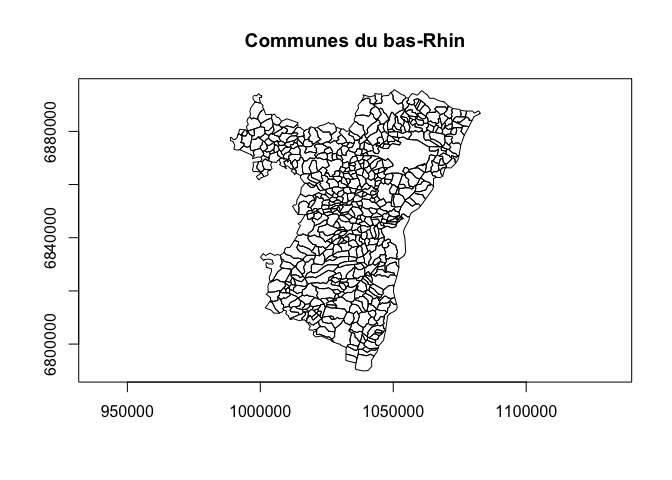

```r
load("Cartofile/carto67.Rda") # st
plot(st, main = "Communes du bas-Rhin", axes = TRUE)
```

Détails sur le fichier et les manipulations possibles:

```r
class(st)
```

```
## [1] "SpatialPolygonsDataFrame"
## attr(,"package")
## [1] "sp"
```

```r
names(st)
```

```
##  [1] "ID_GEOFLA"  "CODE_COMM"  "INSEE_COM"  "NOM_COMM"   "STATUT"
##  [6] "X_CHF_LIEU" "Y_CHF_LIEU" "X_CENTROID" "Y_CENTROID" "Z_MOYEN"
## [11] "SUPERFICIE" "POPULATION" "CODE_CANT"  "CODE_ARR"   "CODE_DEPT"
## [16] "NOM_DEPT"   "CODE_REG"   "NOM_REGION"
```

L’objet *SpatialPolygonsDataFrame* **st** contient les slots suivants:

```r
slotNames(st)
```

```
## [1] "data"        "polygons"    "plotOrder"   "bbox"        "proj4string"
```

Les **données attributaires** sont contenues dans le *slot* **data**, dataframe dont la première ligne contient:

```r
st@data[1,]
```

```
##    ID_GEOFLA CODE_COMM INSEE_COM NOM_COMM         STATUT X_CHF_LIEU
## 22        23       263     67263  LEMBACH Commune simple      10502
##    Y_CHF_LIEU X_CENTROID Y_CENTROID Z_MOYEN SUPERFICIE POPULATION
## 22      68888      10486      68896     307       4873        1.7
##    CODE_CANT CODE_ARR CODE_DEPT NOM_DEPT CODE_REG NOM_REGION
## 22        34        7        67 BAS-RHIN       42     ALSACE
```

Remarques:

- X_CHF_LIEU et Y_CHF_LIEU sont les coordonnées Lambert93 du centre de la ville. Il faut les multiplier par 100 por qu’elles soient cohérentes avec l’échelle de la carte.
- Même remarque pour X_CENTROID, Y_CENTROID coordonnées du centre de la commune.
- Le STATUT de la commune (préfecture, etc.) est en minuscule accentuées au format *latin1* (Windows), ce qui fait apparaître des caractères anormaux si on travaille en UTF8. On peut corriger ce problème avec l’instruction:

```
b <- as.character(st$STATUT)
Encoding(b) <- "latin1"
st$STATUT <- b
```

Nombre de communes dans le bas-Rhin:

```r
nrow(st@data)
```

```
## [1] 527
```

Population du bas-Rhin:

```r
sum(st$POPULATION) * 1000
```

```
## [1] 1091000
```

Le slot **bbox** contient les limites du rectangle englobant dans un tableau:

```r
st@bbox
```

```
##       min     max
## x  988703 1082671
## y 6789936 6895581
```